# Assignment-3

## - Import Libraries

Import necessary libraries used in these assignment.

```python
import numpy as np
import pandas as pd
import copy
import math
import operator
import matplotlib.pyplot as plt
import matplotlib as mpl
```

```python
def splitTrainTest(data,percent):
    total=len(data)
    trainTotal=int(total*percent*0.01)
    testTotal=total-trainTotal
    return (data[0:trainTotal],data[trainTotal:total])
```

```python
def traintestXY(train,test,independentVariable,targetIndex):
    trainX=train[:,independentVariable]
    trainX=((trainX-trainX.mean(axis=0))/trainX.std(axis=0))
    testX=test[:,independentVariable]
    testX=((testX-testX.mean(axis=0))/testX.std(axis=0))
    trainY=train[:,targetIndex]
    trainY=trainY.reshape(-1,1)
    testY=test[:,targetIndex]
    return (trainX,trainY,testX,testY)
```

## Question-2

### Part-1: Logistic Regression Model

**Sigmoid Function** $$ h_ \theta (x) = \frac{\mathrm{1} }{\mathrm{1} + e^- \theta^Tx } $$

```python
def sigmoid(x):
    return 1/(1+np.e**(-x))
```

```python
def logisticLoss(yactual,hx):
    return -np.mean(yactual*np.log(hx)+(1-yactual)*np.log(1-hx))
```

To implement the logistic regression model we carried out gradient decent algorithm to find of optimal value of $\theta$ and intercept to minimize the loss function thereby taking its partial derivative w.r.t $\theta$ and the intercept.

**Loss Function** $$l(\theta ) = \frac{1}{m} \sum_{i=1}^m[-y_i log(h_\theta (x_i) – (1 – y_i) log(1-h_\theta (x_i))]$$

```python
def logistic(data,percent=80,thresold=0.5,independentVariable=[1,2,3,4,5,6,7],targetIndex=8,learningRate=0.1,attr=None,explicitTest=[]):

    if attr!=None:
            if len(explicitTest)>0:
                #one to one
                train=data
                test=explicitTest
                train[:,targetIndex]=[1 if x==attr else 0 for x in train[:,targetIndex]]
            else:
                #one to many
                train,test=splitTrainTest(data,percent)
                train[:,targetIndex]=[1 if x==attr else 0 for x in train[:,targetIndex]]

    else:
        #normal logistic
        train,test=splitTrainTest(data,percent)
        train[:,targetIndex]=[1 if x>=thresold else 0 for x in train[:,targetIndex]]
        test[:,targetIndex]=[1 if x>=thresold else 0 for x in test[:,targetIndex]]

    trainX=train[:,independentVariable]
    trainX=((trainX-trainX.mean(axis=0))/trainX.std(axis=0))
    trainY=train[:,targetIndex]

    testX=test[:,independentVariable]
    testX=((testX-testX.mean(axis=0))/testX.std(axis=0))
    testY=test[:,targetIndex]

    m=len(trainX)
    trainY=trainY.reshape(-1,1)

    theta=np.zeros((len(independentVariable),1))
    intercept=np.zeros((1,1))

    for epoch in range(6000):
        ypred=np.matmul(trainX,theta)+intercept
        hx=sigmoid(ypred)
        dz=hx-trainY
        dTheta=np.matmul(trainX.T,dz)/m
        dintercept=np.sum(dz)

        theta=theta-learningRate*dTheta
        intercept=intercept-learningRate*dintercept
#     print("=========================================")
#     print("Intercept: ")
#     print(intercept)
#     print("Coefficents: ")
#     print(theta)
#     print("=========================================")
    testPred=np.matmul(testX,theta)+intercept

    hxTest=sigmoid(testPred)
    if attr!=None:
        return (hxTest,testY)



    accuracyList=[]
    precisionList=[]
    recallList=[]
    f1ScoreList=[]
    count=0
    TP=0
    TN=0
    FP=0
    FN=0
    precision=0
    recall=0
    for a,b in zip(testY,hxTest):
        orig=a
        if b>=thresold:
            pred=1
        else:
            pred=0
        if orig==pred:
            count+=1
            if pred==1:
                TP+=1
            else:
                TN+=1
        else:
            if pred==1:
                FP+=1
            else:
                FN+=1
#         print("%10s | %10s"%(a,b))
    accuracy=count/len(testY)
    recall=TP/(TP+FN)
    precision=TP/(TP+FP)
    f1score=(2*recall*precision)/(recall+precision)

    return (accuracy,precision,recall,f1score)
```

```python
def runlog():
    data=pd.read_csv("AdmissionDataset/data.csv")
    data=data.sample(frac=1).values
    accuracy,precision,recall,f1score=logistic(data,80,0.5)
    print("=================================")
    print("Accuracy: ",accuracy)
    print("Precision: ",precision)
    print("Recall: ",recall)
    print("f1-score: ",f1score)
    print("=================================")
runlog()
```

```
=================================
Accuracy:  0.9666666666666667
Precision:  0.9659090909090909
Recall:  1.0
f1-score:  0.9826589595375723
=================================
```

### Part-2: Comparision of logistic regression and KNN model

**Distance Measure for KNN-Minowski**

$$ \left(\sum_{i=1}^n |x_i-y_i|^p\right)^{1/p}$$

```python
def distMeasure(dataset,testdataset,targetIndex,p):
    n=len(testdataset)
    dist=0
    for i in range(n):
        if i==targetIndex:continue
        dist+=math.pow(abs(dataset[i]-testdataset[i]),p);
    return math.pow(dist,1/p)
```

```python
def KNNAlgo(train,testRecord,k,targetIndex,p):
    dists={}
    count=0
    if p==3:
        funct=chebyshev
    else:
        funct=distMeasure
    for trainRecord in train:
        dist=funct(trainRecord,testRecord,targetIndex,p)
        dists[(str(trainRecord),trainRecord[targetIndex],count)]=dist
        count+=1
    sortedDict= sorted(dists.items(), key=operator.itemgetter(1))
    labelDict={}
    for i in range(k):
        if sortedDict[i][0][1] in labelDict.keys():
            labelDict[sortedDict[i][0][1]]+=1
        else:
            labelDict[sortedDict[i][0][1]]=1
    return max(labelDict.items(),key=operator.itemgetter(1))[0]
```

```python
def predict(train,test,k,targetIndex,p):
    count=0
    TP=0
    TN=0
    FP=0
    FN=0
    precision=0
    recall=0
    for testRecord in test:
        predicted=KNNAlgo(train,testRecord,k,targetIndex,p)
        actual=testRecord[targetIndex]
        if actual==predicted:
            count+=1
            if predicted==1:
                TP+=1
            else:
                TN+=1
        else:
            if predicted==1:
                FP+=1
            else:
                FN+=1
    accuracy=count/len(test)
    recall=TP/(TP+FN)
    precision=TP/(TP+FP)
    f1score=(2*recall*precision)/(recall+precision)
    return (accuracy,precision,recall,f1score)
```

```python
def compareModels():
    data1=pd.read_csv("AdmissionDataset/data.csv")
    data1=data1.sample(frac=1).values
    data2=copy.deepcopy(data1)
    print("====================================")
    print("Performance of Logistic Regression")
    accuracy,precision,recall,f1score=logistic(data1,80)
    print("=================================")
    print("Accuracy: ",accuracy)
    print("Precision: ",precision)
    print("Recall: ",recall)
    print("f1-score: ",f1score)
    print("=================================")

    data2=data2[:,1:]
    data2[:,7]=[1 if x>0.5 else 0 for x in data2[:,7]]
    train,validate=splitTrainTest(data2,80)
    accuracy,precision,recall,f1score=predict(train,validate,7,7,2)
    print("Performance of KNN model")
    print("====================================")
    print("Accuracy: %f"%(accuracy))
    print("Precision: %f"%(precision))
    print("Recall: %f"%(recall))
    print("f1-score: %f"%(f1score))
    print("====================================")
compareModels()
```

```
====================================
Performance of Logistic Regression
=================================
Accuracy:  0.9333333333333333
Precision:  0.9411764705882353
Recall:  0.9876543209876543
f1-score:  0.963855421686747
=================================
Performance of KNN model
====================================
Accuracy: 0.922222
Precision: 0.930233
Recall: 0.987654
f1-score: 0.958084
====================================
```

### Part 3: Graph showing co-relation between threshold value vs precision and recall

-In logistic regression model, there are so many cadidate values which can be choose as a **thresold** to convert to numerical outcome of sigmoid function into the binary label.

**-Criteria one should use while deciding thresold value**

A ROC(Receiver Operator Characteristic Curve) can help in deciding the best threshold value. It is generated by plotting the True Positive Rate (y-axis) against the False Positive Rate (x-axis) as you vary the threshold for assigning observations to a given class.One should select the best threshold for the trade off you want to make.

**High Threshold :** High specificity, Low sensitivity  
**Low Threshold :** Low specificity, High sensitivity

```python
mpl.rcParams.update(mpl.rcParamsDefault)
def drawGraph(trainFile,percent):
    accuracyList=[]
    precisionList=[]
    recallList=[]
    f1ScoreList=[]
    data=pd.read_csv(trainFile)
    data=data.sample(frac=1).values
    for i in [0.9,0.8,0.7,0.6,0.5,0.4,0.3,0.2,0.1,0]:
#         print(i)
        datatoPass=copy.deepcopy(data)
        accuracy,precision,recall,f1score=logistic(datatoPass,percent,i)
        accuracyList.append(accuracy)
        precisionList.append(precision)
        recallList.append(recall)
        f1ScoreList.append(f1score)

    plt.title("Correlation between thresold value and performance measures")
    plt.xlabel("Thresold value")
    plt.ylabel("Performance Measures")
    plt.grid(True)
#     plt.plot([0.9,0.8,0.7,0.6,0.5,0.4,0.3,0.2,0.1,0],accuracyList ,color="green", linewidth=2.5,label="Accuracy")
    plt.plot([0.9,0.8,0.7,0.6,0.5,0.4,0.3,0.2,0.1,0], precisionList,color="orange", linewidth=2.5,label="Precision")
#     plt.plot([ i*0.1 for i in range(0,10)], f1ScoreList,color="b", linewidth=2.5,label="F1-Score")
    plt.plot([0.9,0.8,0.7,0.6,0.5,0.4,0.3,0.2,0.1,0], recallList,color="m", linewidth=2.5,label="Recall")

    plt.legend(loc=3)
    plt.show()
```

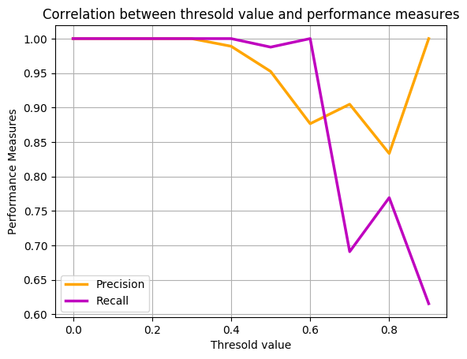

```python
drawGraph("AdmissionDataset/data.csv",80)
```

## Question-3 Logistic regression using One vs All and One vs One approaches.

### Part-1: Logistic regression using one vs all

One-vs-All strategy involves training a single classifier per class, with the samples of that class as positive samples and all other samples as negatives. This strategy requires the base classifiers to produce a real-valued confidence score for its decision.

It produces K classifiers

Making decisions means applying all classifiers to an unseen sample x and predicting the label k for which the corresponding classifier reports the highest confidence score: $${\displaystyle {\hat {y}}={\underset {k\in \{1\ldots K\}}{\arg \!\max }}\;f_{k}(x)} $$

```python
def oneToMany(trainF,percent):
    data=pd.read_csv(trainF,delimiter=";",header=1).values
    data=data.sample(frac=1).values
    uniq=np.unique(data[:,11])
    final=[]
    for i in uniq:
        datatoPass=copy.deepcopy(data)
        predictions,originalY=logistic(datatoPass,percent,0.5,[i for i in range(11)],11,0.01,i)
        final.append(predictions)
    i=0
    count=0
    for i in range(len(originalY)):
        mx=-1
        val=0
        for j in range(len(final)):
            if final[j][i]>mx:
                mx=final[j][i]
                val=uniq[j]
        if val==originalY[i]:
            count+=1
    print("Accuracy: ",count/len(originalY))
```

```python
oneToMany("wine-quality/data.csv",80)
```

[output not shown]

### Part-1: Logistic regression using one vs one

In the one-vs-one (OvO) reduction, one trains K (K − 1) / 2 binary classifiers for a K-way multiclass problem; each receives the samples of a pair of classes from the original training set, and must learn to distinguish these two classes. At prediction time, a voting scheme is applied: all K (K − 1) / 2 classifiers are applied to an unseen sample and the class that got the highest number of "+1" predictions gets predicted by the combined classifier.

```python
def oneToone(trainF,percent):
    data=pd.read_csv(trainF,delimiter=";",header=1)
    data=data.sample(frac=1).values
    train,test=splitTrainTest(data,80)
    dataDict={}
    for row in train:
        dataDict.setdefault(row[11],[]).append(row)
    uniq=list(dataDict.keys())
    n=len(uniq)
    final=[] #contains prediction values list for all pairs
    pairs=[]
    for i in range(n-1):
        for j in range(i+1,n):
            datatoPass=np.array(dataDict[uniq[i]]+dataDict[uniq[j]])
            testtoPass=copy.deepcopy(test)
            predictions,originalY=logistic(datatoPass,percent,0.5,[i for i in range(11)],11,0.01,uniq[i],testtoPass)
            final.append(predictions)
            pairs.append((uniq[i],uniq[j]))
    totalPairs=len(pairs)
    count=0
    bins={}
    for i in range(len(originalY)):
        mx=-1
        for j in range(len(pairs)):
            mxpair=pairs[j]
            if final[j][i]>=0.5:
                bins[mxpair[0]]=bins.get(mxpair[0],0)+1
            else:
                bins[mxpair[1]]=bins.get(mxpair[1],0)+1
        pred=max(bins, key=bins.get)
        if pred==originalY[i]:
            count+=1
    print("Accuracy: ",count/len(originalY))
```

```python
oneToone("wine-quality/data.csv",80)
```

```
Accuracy:  0.481859410430839
```